# Project VI

Marcel Poblet

November 13, 2016

# Iowa House Pricing

## About

We will be taking a look into the different price ranges of houses sold in Ames, Iowa from 2006-2010. Our goal is to find the most significant predictors for the selling price of houses during this time period. We are going to take a step-by-step approach to building the final model by adding and removing predictors until all predictors are significant to the standard of .05. The data was collected by Ames, Iowa Assessors Office.

Let’s start by loading the data into a dataframe called “iowaHousing”, and ensure your working directory is the same as where the “.csv” file was saved to.

```r
iowaHousing <- read.csv("IowaHousing.csv")
```

The data consists of 2930 observations and 81 variables. The IowaHousing.txt file consists of the information about each column in our data frame. Use that to clarify any questions about the columns we use.

## First Model

The first model we will create consists of the overall condition of the house. How well was the home maintained before the sale and was there a direct relation to its final selling price? There should be a direct relation between how well the house has been maintained and its value. A slightly cheaper home may maintain its value if it was not neglected and only requires minimum renevations.

```r
houseCondModel <- lm(SalePrice ~ as.factor(Overall.Cond), data=iowaHousing)
summary(houseCondModel)
```

```
##
## Call:
## lm(formula = SalePrice ~ as.factor(Overall.Cond), data = iowaHousing)
##
## Residuals:
##     Min      1Q  Median      3Q     Max
## -192927  -43002  -14014   27236  604622
##
## Coefficients:
##                          Estimate Std. Error t value Pr(>|t|)
## (Intercept)                 69981      27871   2.511  0.01210 *
## as.factor(Overall.Cond)2    46081      36340   1.268  0.20488
## as.factor(Overall.Cond)3    26013      29758   0.874  0.38212
## as.factor(Overall.Cond)4    50943      28821   1.768  0.07724 .
## as.factor(Overall.Cond)5   136046      27930   4.871 1.17e-06 ***
## as.factor(Overall.Cond)6    80397      28054   2.866  0.00419 **
## as.factor(Overall.Cond)7    83021      28120   2.952  0.00318 **
## as.factor(Overall.Cond)8    84794      28541   2.971  0.00299 **
## as.factor(Overall.Cond)9   129785      30157   4.304 1.74e-05 ***
## ---
## Signif. codes:  0 '***' 0.001 '**' 0.01 '*' 0.05 '.' 0.1 ' ' 1
##
## Residual standard error: 73740 on 2921 degrees of freedom
## Multiple R-squared:  0.1503, Adjusted R-squared:  0.148
## F-statistic: 64.58 on 8 and 2921 DF,  p-value: < 2.2e-16
```

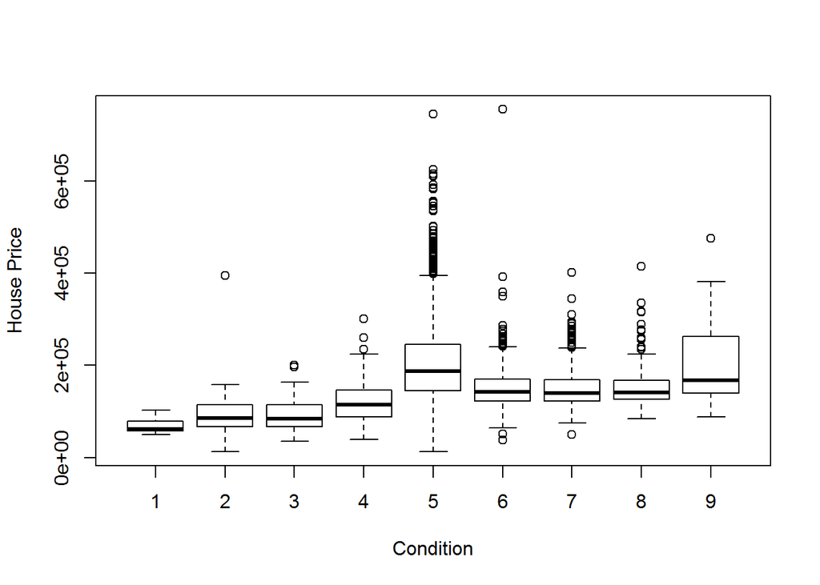

We can see a slight upward trend when looking at the relation of a home’s condition and price. Once you get to the average condition there is a large range of different prices associated with it. This can be caused by the categorizing of each style of home since the average can be different for lower and higher priced homes.

## Second Model

Let’s continue and add the house style. If a house has more than one story and is finished, that might have an impact on the selling price. This can fix the issue presented when just comparing overall condition of the homes without haivng them categorized.

```r
styleCondModel <- lm(SalePrice ~ as.factor(Overall.Cond) + House.Style, data = iowaHousing)
summary(styleCondModel)
```

```
##
## Call:
## lm(formula = SalePrice ~ as.factor(Overall.Cond) + House.Style,
##     data = iowaHousing)
##
## Residuals:
##     Min      1Q  Median      3Q     Max
## -187264  -43401  -12162   27396  581301
##
## Coefficients:
##                          Estimate Std. Error t value Pr(>|t|)
## (Intercept)                 37750      27594   1.368 0.171411
## as.factor(Overall.Cond)2    55061      35606   1.546 0.122119
## as.factor(Overall.Cond)3    35850      29203   1.228 0.219701
## as.factor(Overall.Cond)4    63634      28268   2.251 0.024452 *
## as.factor(Overall.Cond)5   139185      27399   5.080 4.01e-07 ***
## as.factor(Overall.Cond)6    89983      27515   3.270 0.001087 **
## as.factor(Overall.Cond)7    93855      27575   3.404 0.000674 ***
## as.factor(Overall.Cond)8    93430      27967   3.341 0.000846 ***
## as.factor(Overall.Cond)9   128832      29568   4.357 1.36e-05 ***
## House.Style1.5Unf          -16772      17092  -0.981 0.326519
## House.Style1Story           23429       4602   5.091 3.79e-07 ***
## House.Style2.5Fin           81773      25986   3.147 0.001667 **
## House.Style2.5Unf           40862      15323   2.667 0.007701 **
## House.Style2Story           45967       4916   9.351  < 2e-16 ***
## House.StyleSFoyer          -10985       8949  -1.227 0.219754
## House.StyleSLvl             12593       7629   1.651 0.098918 .
## ---
## Signif. codes:  0 '***' 0.001 '**' 0.01 '*' 0.05 '.' 0.1 ' ' 1
##
## Residual standard error: 72100 on 2914 degrees of freedom
## Multiple R-squared:  0.1895, Adjusted R-squared:  0.1853
## F-statistic: 45.42 on 15 and 2914 DF,  p-value: < 2.2e-16
```

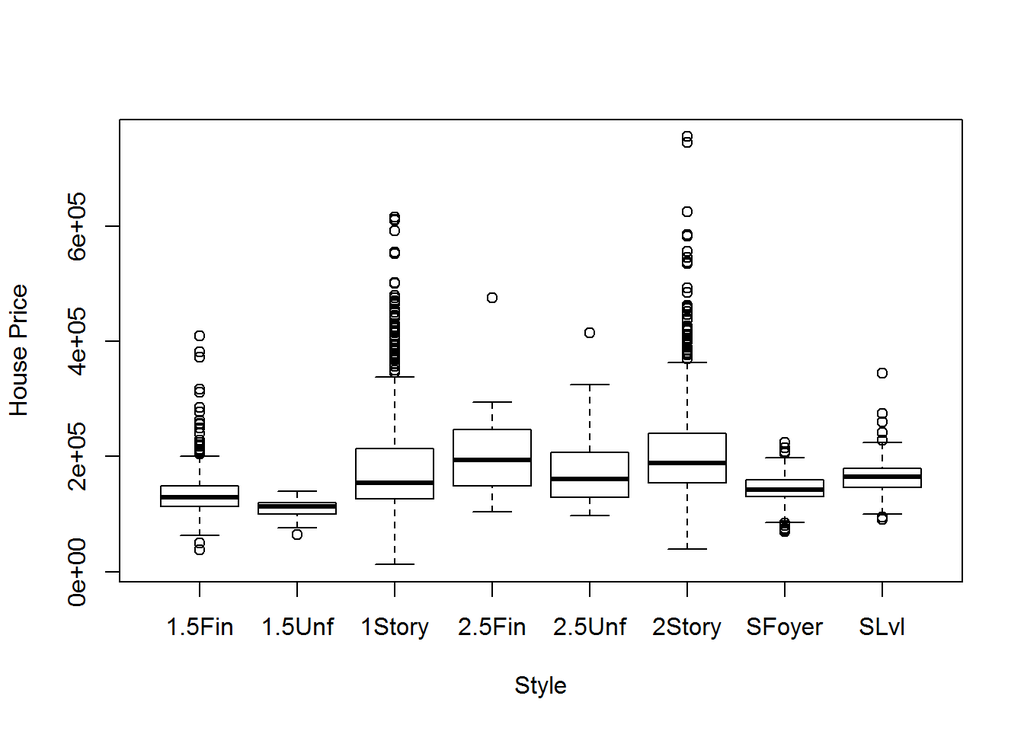

We can see that the finished levels were slightly higher than the unfinished. Split foyer, 1.5 story unfinished, and split level didn’t show significance in determining the cost of the house. Looking at the plot above, those three home styles don’t show a large variability in price range. This seems to be a limiting factor as there aren’t as many home styles for those categories to justifiy a price difference based on home style.

## Third Model

The next model will add to the overall quality of the house. This is the quality of the materials used for the construction of the home. My assumption is the higher quality homes will lose a larger amount of value if their condition is poor.

```r
condStyleQualModel <- lm(SalePrice ~ as.factor(Overall.Cond) + House.Style + as.factor(Overall.Qual),
                    data = iowaHousing)
summary(condStyleQualModel)
```

```
##
## Call:
## lm(formula = SalePrice ~ as.factor(Overall.Cond) + House.Style +
##     as.factor(Overall.Qual), data = iowaHousing)
##
## Residuals:
##     Min      1Q  Median      3Q     Max
## -295805  -23033   -2650   18889  302175
##
## Coefficients:
##                           Estimate Std. Error t value Pr(>|t|)
## (Intercept)                  31570      25232   1.251  0.21097
## as.factor(Overall.Cond)2     13691      21557   0.635  0.52542
## as.factor(Overall.Cond)3      4643      17663   0.263  0.79267
## as.factor(Overall.Cond)4     27668      17289   1.600  0.10964
## as.factor(Overall.Cond)5     35480      16910   2.098  0.03597 *
## as.factor(Overall.Cond)6     32500      16950   1.917  0.05529 .
## as.factor(Overall.Cond)7     37523      16985   2.209  0.02724 *
## as.factor(Overall.Cond)8     32044      17223   1.861  0.06291 .
## as.factor(Overall.Cond)9     27140      18170   1.494  0.13537
## House.Style1.5Unf           -28472      10228  -2.784  0.00541 **
## House.Style1Story             5964       2772   2.151  0.03154 *
## House.Style2.5Fin            34706      15580   2.228  0.02599 *
## House.Style2.5Unf            -6896       9233  -0.747  0.45515
## House.Style2Story            15377       3014   5.102 3.57e-07 ***
## House.StyleSFoyer             3130       5358   0.584  0.55915
## House.StyleSLvl               6048       4590   1.318  0.18773
## as.factor(Overall.Qual)2     -5953      24992  -0.238  0.81174
## as.factor(Overall.Qual)3     21754      23055   0.944  0.34546
## as.factor(Overall.Qual)4     36988      22366   1.654  0.09829 .
## as.factor(Overall.Qual)5     63971      22275   2.872  0.00411 **
## as.factor(Overall.Qual)6     88098      22317   3.948 8.08e-05 ***
## as.factor(Overall.Qual)7    128588      22346   5.754 9.60e-09 ***
## as.factor(Overall.Qual)8    194577      22389   8.691  < 2e-16 ***
## as.factor(Overall.Qual)9    292880      22644  12.934  < 2e-16 ***
## as.factor(Overall.Qual)10   373378      23599  15.822  < 2e-16 ***
## ---
## Signif. codes:  0 '***' 0.001 '**' 0.01 '*' 0.05 '.' 0.1 ' ' 1
##
## Residual standard error: 43120 on 2905 degrees of freedom
## Multiple R-squared:  0.7111, Adjusted R-squared:  0.7087
## F-statistic: 297.9 on 24 and 2905 DF,  p-value: < 2.2e-16
```

## Fourth Model

This next model will remove the House style and see how that affects the predictors.

```r
condQualModel <- lm(SalePrice ~ as.factor(Overall.Cond) + as.factor(Overall.Qual), data = iowaHousing)
summary(condQualModel)
```

```
##
## Call:
## lm(formula = SalePrice ~ as.factor(Overall.Cond) + as.factor(Overall.Qual),
##     data = iowaHousing)
##
## Residuals:
##     Min      1Q  Median      3Q     Max
## -290793  -24036   -2915   19085  308644
##
## Coefficients:
##                           Estimate Std. Error t value Pr(>|t|)
## (Intercept)                  38821      25275   1.536  0.12466
## as.factor(Overall.Cond)2     12652      21680   0.584  0.55955
## as.factor(Overall.Cond)3      2419      17730   0.136  0.89150
## as.factor(Overall.Cond)4     25529      17365   1.470  0.14164
## as.factor(Overall.Cond)5     34780      16966   2.050  0.04046 *
## as.factor(Overall.Cond)6     30344      17015   1.783  0.07463 .
## as.factor(Overall.Cond)7     34875      17056   2.045  0.04097 *
## as.factor(Overall.Cond)8     30060      17307   1.737  0.08251 .
## as.factor(Overall.Cond)9     28082      18255   1.538  0.12406
## as.factor(Overall.Qual)2     -5593      25191  -0.222  0.82432
## as.factor(Overall.Qual)3     21014      23227   0.905  0.36569
## as.factor(Overall.Qual)4     37381      22526   1.659  0.09713 .
## as.factor(Overall.Qual)5     63971      22439   2.851  0.00439 **
## as.factor(Overall.Qual)6     90515      22462   4.030 5.73e-05 ***
## as.factor(Overall.Qual)7    132315      22486   5.884 4.45e-09 ***
## as.factor(Overall.Qual)8    197702      22544   8.770  < 2e-16 ***
## as.factor(Overall.Qual)9    295245      22807  12.946  < 2e-16 ***
## as.factor(Overall.Qual)10   377192      23748  15.883  < 2e-16 ***
## ---
## Signif. codes:  0 '***' 0.001 '**' 0.01 '*' 0.05 '.' 0.1 ' ' 1
##
## Residual standard error: 43460 on 2912 degrees of freedom
## Multiple R-squared:  0.7057, Adjusted R-squared:  0.704
## F-statistic: 410.7 on 17 and 2912 DF,  p-value: < 2.2e-16
```

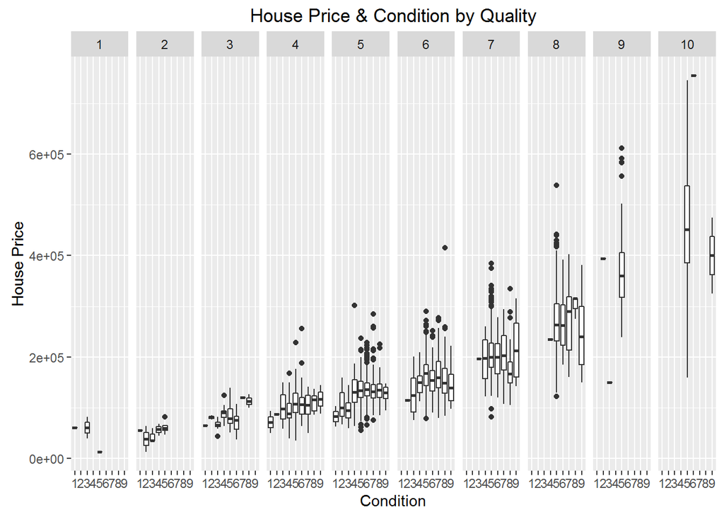

Overall quality seems to have a large amount of significance to the cost of the house. It does show the least significance on houses that are lower in quality. The plot shows the variability of lower quality homes staying below average conditions. As the quality of the homes increase there is a larger range in condition, but there is still an increase in price overall. Once the quality is at max the condition of homes don’t fall bellow average. This shows how condition isn’t a suitable predictor of house price.

## Fifth Model

Lets remove overall condition of the house since we saw how it didn’t significantly affect the house value.

```r
qualModel <- lm(SalePrice ~ as.factor(Overall.Qual), data = iowaHousing)
summary(qualModel)
```

```
##
## Call:
## lm(formula = SalePrice ~ as.factor(Overall.Qual), data = iowaHousing)
##
## Residuals:
##     Min      1Q  Median      3Q     Max
## -290217  -23985   -2691   19339  304783
##
## Coefficients:
##                           Estimate Std. Error t value Pr(>|t|)
## (Intercept)                  48725      21829   2.232  0.02568 *
## as.factor(Overall.Qual)2      3600      24963   0.144  0.88533
## as.factor(Overall.Qual)3     34461      22895   1.505  0.13238
## as.factor(Overall.Qual)4     57760      22022   2.623  0.00876 **
## as.factor(Overall.Qual)5     86028      21882   3.931 8.64e-05 ***
## as.factor(Overall.Qual)6    113405      21889   5.181 2.36e-07 ***
## as.factor(Overall.Qual)7    156301      21902   7.137 1.20e-12 ***
## as.factor(Overall.Qual)8    222189      21954  10.121  < 2e-16 ***
## as.factor(Overall.Qual)9    319612      22233  14.375  < 2e-16 ***
## as.factor(Overall.Qual)10   401492      23195  17.310  < 2e-16 ***
## ---
## Signif. codes:  0 '***' 0.001 '**' 0.01 '*' 0.05 '.' 0.1 ' ' 1
##
## Residual standard error: 43660 on 2920 degrees of freedom
## Multiple R-squared:  0.7023, Adjusted R-squared:  0.7013
## F-statistic: 765.2 on 9 and 2920 DF,  p-value: < 2.2e-16
```

We are significant to the standard of .05 with all except fair and poor quality. I’m fairly certain there is some factor that causes this random fluctuation in price for lower quality homes.

### Revision

Before we move on let’s make a change to the overall quality column of our data since the variability is small for the homes for fair, poor, and very poor. Let’s combine them into one labled “0” so anything falling beneath below average is considered bad for overall quality of a home.

```r
bad <- function(n){
  if(n < 4) 0 else n
}
iowaHousing$Overall.Qual <- sapply(iowaHousing$Overall.Qual, bad)
```

## Seventh Model

I’m curious if the type of home can make a large impact of the price. Let’s add building type to our model.

```r
qualTypeModel <- lm(SalePrice ~ as.factor(Overall.Qual) + Bldg.Type, data = iowaHousing)
summary(qualTypeModel)
```

```
##
## Call:
## lm(formula = SalePrice ~ as.factor(Overall.Qual) + Bldg.Type,
##     data = iowaHousing)
##
## Residuals:
##     Min      1Q  Median      3Q     Max
## -291126  -24315   -2523   18830  303874
##
## Coefficients:
##                           Estimate Std. Error t value Pr(>|t|)
## (Intercept)                  74250       5638  13.169  < 2e-16 ***
## as.factor(Overall.Qual)4     37065       6307   5.877 4.64e-09 ***
## as.factor(Overall.Qual)5     61921       5818  10.643  < 2e-16 ***
## as.factor(Overall.Qual)6     93273       5858  15.922  < 2e-16 ***
## as.factor(Overall.Qual)7    135491       5905  22.944  < 2e-16 ***
## as.factor(Overall.Qual)8    202279       6096  33.180  < 2e-16 ***
## as.factor(Overall.Qual)9    299614       6998  42.814  < 2e-16 ***
## as.factor(Overall.Qual)10   376876       9487  39.726  < 2e-16 ***
## Bldg.Type2fmCon             -11315       5512  -2.053   0.0402 *
## Bldg.TypeDuplex              -1762       4210  -0.418   0.6757
## Bldg.TypeTwnhs              -41647       4353  -9.568  < 2e-16 ***
## Bldg.TypeTwnhsE             -28163       2965  -9.499  < 2e-16 ***
## ---
## Signif. codes:  0 '***' 0.001 '**' 0.01 '*' 0.05 '.' 0.1 ' ' 1
##
## Residual standard error: 42480 on 2918 degrees of freedom
## Multiple R-squared:  0.7183, Adjusted R-squared:  0.7173
## F-statistic: 676.5 on 11 and 2918 DF,  p-value: < 2.2e-16
```

This is interesting to see that there is an interaction with our existing predictors. Let’s view just building type in relation to price.

```r
houseTypeModel <- lm(SalePrice ~ Bldg.Type, data = iowaHousing)
summary(houseTypeModel)
```

```
##
## Call:
## lm(formula = SalePrice ~ Bldg.Type, data = iowaHousing)
##
## Residuals:
##     Min      1Q  Median      3Q     Max
## -172023  -50509  -16730   32188  570188
##
## Coefficients:
##                 Estimate Std. Error t value Pr(>|t|)
## (Intercept)       184812       1595 115.863  < 2e-16 ***
## Bldg.Type2fmCon   -59230      10102  -5.863 5.06e-09 ***
## Bldg.TypeDuplex   -45003       7691  -5.851 5.41e-09 ***
## Bldg.TypeTwnhs    -48878       7977  -6.127 1.01e-09 ***
## Bldg.TypeTwnhsE     7500       5388   1.392    0.164
## ---
## Signif. codes:  0 '***' 0.001 '**' 0.01 '*' 0.05 '.' 0.1 ' ' 1
##
## Residual standard error: 78550 on 2925 degrees of freedom
## Multiple R-squared:  0.03453,    Adjusted R-squared:  0.03321
## F-statistic: 26.15 on 4 and 2925 DF,  p-value: < 2.2e-16
```

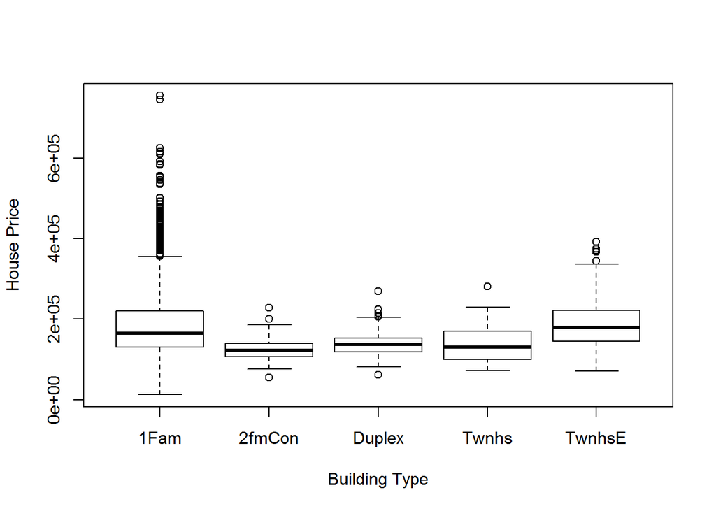

It seems as though there is a difference in price in relation to building type. When our predictors are taken out the significance of a duplex building type increases and townhouse end unit decreases. There is a large amount of one family building types and this can make it more difficult to predict the price when the range is so large compared to the others.

## Eighth Model

The next thing I feel can affect house price would be the external quality of the home.

```r
typeExModel <- lm(SalePrice ~ Bldg.Type + Exter.Qual + as.factor(Overall.Qual), data = iowaHousing)
summary(typeExModel)
```

```
##
## Call:
## lm(formula = SalePrice ~ Bldg.Type + Exter.Qual + as.factor(Overall.Qual),
##     data = iowaHousing)
##
## Residuals:
##     Min      1Q  Median      3Q     Max
## -293683  -23608   -2879   18383  315918
##
## Coefficients:
##                           Estimate Std. Error t value Pr(>|t|)
## (Intercept)                 128095       8456  15.148  < 2e-16 ***
## Bldg.Type2fmCon              -6938       5441  -1.275    0.202
## Bldg.TypeDuplex               1377       4115   0.335    0.738
## Bldg.TypeTwnhs              -42248       4246  -9.949  < 2e-16 ***
## Bldg.TypeTwnhsE             -33626       2928 -11.483  < 2e-16 ***
## Exter.QualFa                -71455       9707  -7.361 2.36e-13 ***
## Exter.QualGd                -24600       5888  -4.178 3.02e-05 ***
## Exter.QualTA                -51409       6302  -8.158 5.02e-16 ***
## as.factor(Overall.Qual)4     34708       6271   5.535 3.39e-08 ***
## as.factor(Overall.Qual)5     57930       5869   9.871  < 2e-16 ***
## as.factor(Overall.Qual)6     85902       5916  14.521  < 2e-16 ***
## as.factor(Overall.Qual)7    114770       6131  18.720  < 2e-16 ***
## as.factor(Overall.Qual)8    173622       6486  26.768  < 2e-16 ***
## as.factor(Overall.Qual)9    258358       7945  32.518  < 2e-16 ***
## as.factor(Overall.Qual)10   325588      10976  29.662  < 2e-16 ***
## ---
## Signif. codes:  0 '***' 0.001 '**' 0.01 '*' 0.05 '.' 0.1 ' ' 1
##
## Residual standard error: 41430 on 2915 degrees of freedom
## Multiple R-squared:  0.7323, Adjusted R-squared:  0.731
## F-statistic: 569.6 on 14 and 2915 DF,  p-value: < 2.2e-16
```

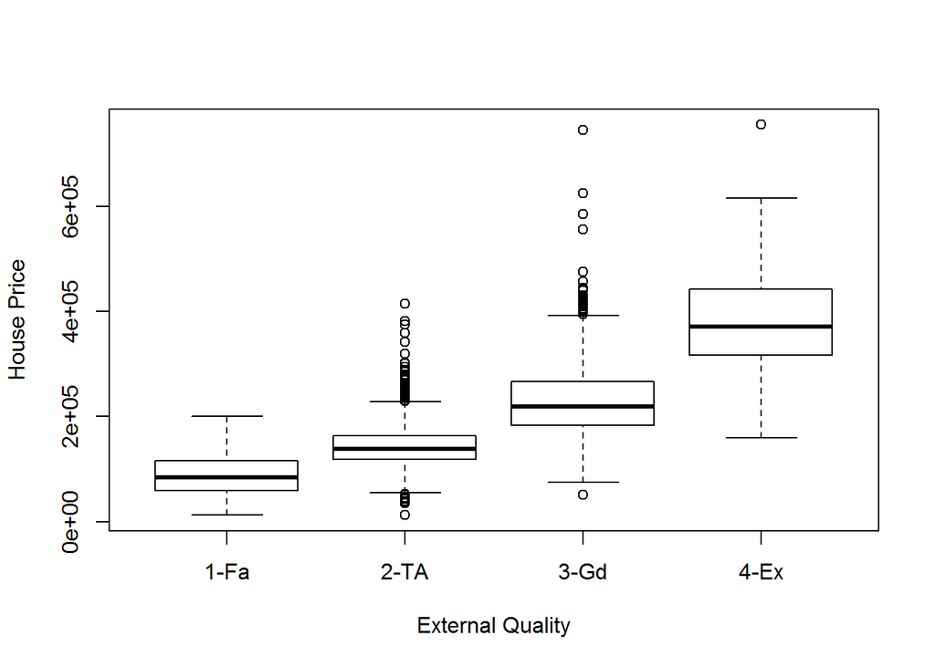

The external quality of the home seems to have a significant impact on the price of the home. Excellent is the highest, good is second, typical/average, and then fair. The better the quality the higher the price becomes. This is however another interaction.

## Ninth Model

I’m going to remove the Building Type of the homes. Since building type and external quality were both interactions, let’s remove the least siginificant of the two.

```r
exQualModel <- lm(SalePrice ~ Exter.Qual + as.factor(Overall.Qual), data = iowaHousing)
summary(exQualModel)
```

```
##
## Call:
## lm(formula = SalePrice ~ Exter.Qual + as.factor(Overall.Qual),
##     data = iowaHousing)
##
## Residuals:
##     Min      1Q  Median      3Q     Max
## -292509  -23746   -2676   19254  316174
##
## Coefficients:
##                           Estimate Std. Error t value Pr(>|t|)
## (Intercept)                  57216       8270   6.919 5.57e-12 ***
## Exter.Qual2-TA               19422       7609   2.553   0.0107 *
## Exter.Qual3-Gd               41831       7934   5.272 1.44e-07 ***
## Exter.Qual4-Ex               65514       9963   6.576 5.70e-11 ***
## as.factor(Overall.Qual)4     30197       6481   4.659 3.32e-06 ***
## as.factor(Overall.Qual)5     57107       6074   9.402  < 2e-16 ***
## as.factor(Overall.Qual)6     81037       6116  13.249  < 2e-16 ***
## as.factor(Overall.Qual)7    112628       6348  17.743  < 2e-16 ***
## as.factor(Overall.Qual)8    171492       6716  25.535  < 2e-16 ***
## as.factor(Overall.Qual)9    256661       8228  31.193  < 2e-16 ***
## as.factor(Overall.Qual)10   329779      11363  29.022  < 2e-16 ***
## ---
## Signif. codes:  0 '***' 0.001 '**' 0.01 '*' 0.05 '.' 0.1 ' ' 1
##
## Residual standard error: 42920 on 2919 degrees of freedom
## Multiple R-squared:  0.7123, Adjusted R-squared:  0.7113
## F-statistic: 722.6 on 10 and 2919 DF,  p-value: < 2.2e-16
```

## Tenth Model

Let’s add central air to our model. If this is not included it can be a large expense to add to a home that is already built.

```r
qualExAirModel <- lm(SalePrice ~ Exter.Qual + as.factor(Overall.Qual) + Central.Air, data = iowaHousing)
summary(qualExAirModel)
```

```
##
## Call:
## lm(formula = SalePrice ~ Exter.Qual + as.factor(Overall.Qual) +
##     Central.Air, data = iowaHousing)
##
## Residuals:
##     Min      1Q  Median      3Q     Max
## -292504  -23404   -2783   18277  316123
##
## Coefficients:
##                           Estimate Std. Error t value Pr(>|t|)
## (Intercept)                  55028       8188   6.721 2.16e-11 ***
## Exter.Qual2-TA                8831       7646   1.155 0.248238
## Exter.Qual3-Gd               30093       7988   3.767 0.000168 ***
## Exter.Qual4-Ex               53721       9969   5.389 7.67e-08 ***
## as.factor(Overall.Qual)4     21082       6515   3.236 0.001226 **
## as.factor(Overall.Qual)5     44720       6209   7.202 7.51e-13 ***
## as.factor(Overall.Qual)6     67562       6285  10.749  < 2e-16 ***
## as.factor(Overall.Qual)7     99110       6507  15.230  < 2e-16 ***
## as.factor(Overall.Qual)8    158131       6855  23.068  < 2e-16 ***
## as.factor(Overall.Qual)9    243115       8318  29.226  < 2e-16 ***
## as.factor(Overall.Qual)10   316264      11372  27.811  < 2e-16 ***
## Central.AirY                 27492       3459   7.947 2.70e-15 ***
## ---
## Signif. codes:  0 '***' 0.001 '**' 0.01 '*' 0.05 '.' 0.1 ' ' 1
##
## Residual standard error: 42480 on 2918 degrees of freedom
## Multiple R-squared:  0.7184, Adjusted R-squared:  0.7173
## F-statistic: 676.6 on 11 and 2918 DF,  p-value: < 2.2e-16
```

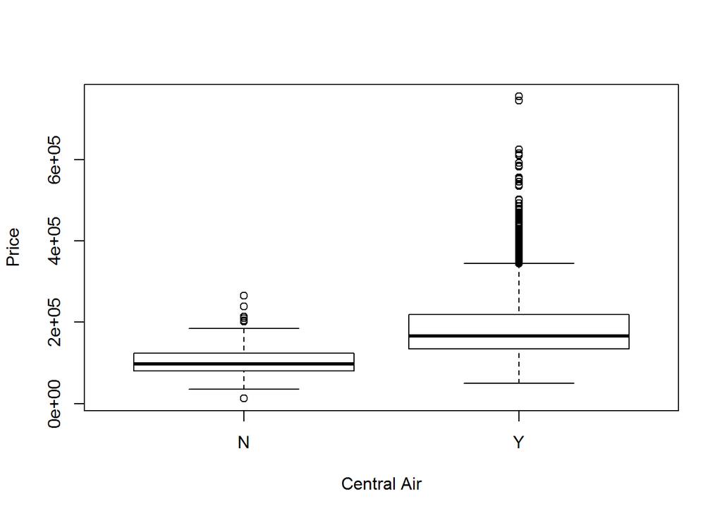

The prescence of central Air does increase the value of the home.

## Eleventh Model

Let’s add number of rooms to our model. We will use a function to seperate homes with five or less rooms and call them “Average”. Homes with more than five rooms will be called “Excess”

```r
rooms <- function(n){
  if(n <= 5) "Average" else ("Excess")
}

iowaHousing$TotRms.AbvGrd <- sapply(iowaHousing$TotRms.AbvGrd, rooms)

qualExAirRoomModel <- lm(SalePrice ~ Exter.Qual + as.factor(Overall.Qual) + Central.Air + TotRms.AbvGrd, data = iowaHousing)
summary(qualExAirRoomModel)
```

```
##
## Call:
## lm(formula = SalePrice ~ Exter.Qual + as.factor(Overall.Qual) +
##     Central.Air + TotRms.AbvGrd, data = iowaHousing)
##
## Residuals:
##     Min      1Q  Median      3Q     Max
## -292367  -22179   -2837   16861  314850
##
## Coefficients:
##                           Estimate Std. Error t value Pr(>|t|)
## (Intercept)                  44398       7983   5.562 2.91e-08 ***
## Exter.Qual2-TA                9364       7419   1.262  0.20699
## Exter.Qual3-Gd               31238       7751   4.030 5.72e-05 ***
## Exter.Qual4-Ex               53455       9673   5.526 3.56e-08 ***
## as.factor(Overall.Qual)4     19915       6322   3.150  0.00165 **
## as.factor(Overall.Qual)5     39746       6036   6.585 5.37e-11 ***
## as.factor(Overall.Qual)6     59974       6124   9.793  < 2e-16 ***
## as.factor(Overall.Qual)7     88009       6367  13.823  < 2e-16 ***
## as.factor(Overall.Qual)8    147434       6698  22.012  < 2e-16 ***
## as.factor(Overall.Qual)9    230541       8124  28.376  < 2e-16 ***
## as.factor(Overall.Qual)10   302844      11078  27.337  < 2e-16 ***
## Central.AirY                 27617       3356   8.228 2.83e-16 ***
## TotRms.AbvGrdExcess          24054       1780  13.515  < 2e-16 ***
## ---
## Signif. codes:  0 '***' 0.001 '**' 0.01 '*' 0.05 '.' 0.1 ' ' 1
##
## Residual standard error: 41210 on 2917 degrees of freedom
## Multiple R-squared:  0.735,  Adjusted R-squared:  0.7339
## F-statistic: 674.1 on 12 and 2917 DF,  p-value: < 2.2e-16
```

We can see the significance that the amount of rooms have on the price of the house.

## Final Model

With the models we have produced previously, it has led to the final model consisting of Overall Quality, External Quality, and Total Rooms Above Ground.

```r
qualExRoomModel <- lm(SalePrice ~ Exter.Qual + as.factor(Overall.Qual) + TotRms.AbvGrd, data = iowaHousing)
summary(qualExRoomModel)
```

```
##
## Call:
## lm(formula = SalePrice ~ Exter.Qual + as.factor(Overall.Qual) +
##     TotRms.AbvGrd, data = iowaHousing)
##
## Residuals:
##     Min      1Q  Median      3Q     Max
## -292373  -22829   -2854   17578  314903
##
## Coefficients:
##                           Estimate Std. Error t value Pr(>|t|)
## (Intercept)                  46615       8069   5.777 8.41e-09 ***
## Exter.Qual2-TA               20003       7389   2.707  0.00682 **
## Exter.Qual3-Gd               43026       7704   5.585 2.56e-08 ***
## Exter.Qual4-Ex               65303       9674   6.751 1.77e-11 ***
## as.factor(Overall.Qual)4     29073       6294   4.619 4.01e-06 ***
## as.factor(Overall.Qual)5     52198       5909   8.833  < 2e-16 ***
## as.factor(Overall.Qual)6     73522       5966  12.324  < 2e-16 ***
## as.factor(Overall.Qual)7    101608       6219  16.339  < 2e-16 ***
## as.factor(Overall.Qual)8    160873       6570  24.488  < 2e-16 ***
## as.factor(Overall.Qual)9    244169       8044  30.354  < 2e-16 ***
## as.factor(Overall.Qual)10   316442      11079  28.563  < 2e-16 ***
## TotRms.AbvGrdExcess          24013       1800  13.340  < 2e-16 ***
## ---
## Signif. codes:  0 '***' 0.001 '**' 0.01 '*' 0.05 '.' 0.1 ' ' 1
##
## Residual standard error: 41680 on 2918 degrees of freedom
## Multiple R-squared:  0.7288, Adjusted R-squared:  0.7278
## F-statistic: 712.9 on 11 and 2918 DF,  p-value: < 2.2e-16
```

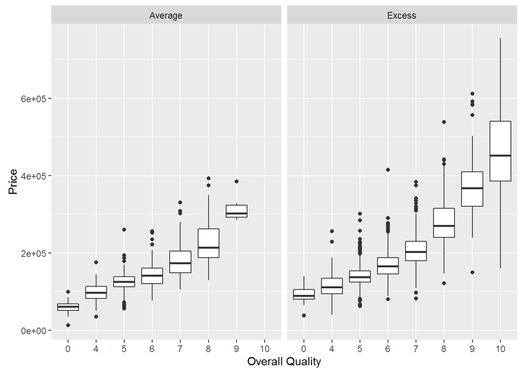

These predictors are all significant to the standard of .05 and an adjusted R<sup>2</sup> of 0.73. This adjusted R<sup>2</sup> shows how close our predictors are to the fitted regression line of the data. We were at 73% variability to our data. The test statistic is 712.9 and the p-value is 2.2e-16

$\widehat{PRICE} = 4.661481\times 10^{4} + 2.000302\times 10^{4}*Exter.Qual2TA + 4.30264\times 10^{4}*Exter.Qual3Gd +$ $6.530263\times 10^{4}*Exter.Qual4Ex + 2.907303\times 10^{4}*Overall.Qual4 + 5.219798\times 10^{4}*Overall.Qual5 +$ $7.352206\times 10^{4}*Overall.Qual6 + 1.0160764\times 10^{5}*Overall.Qual7 + 1.6087298\times 10^{5}*Overall.Qual8 +$ $2.4416905\times 10^{5}*Overall.Qual9 + 3.164424\times 10^{5}*Overall.Qual10 + 2.401325\times 10^{4}*TotalRoomsExcess$